# NRG Neurophys Results

# Methods Exerpt

### Neurophysiology

Single neurons in NRG were isolated using a tungsten micro-electrode (Micro Probes), amplified, filtered and saved for offline analysis. The anterior/posterior position of the electrode in the chamber was chosen using the characteristic firing pattern of the abducens motor nucleus as a landmark. We close electrode tracts that traveled posterior to the nucleus to avoid damaging motor neurons, and continued deeper. On most tracts, the characteristic population bursting for ipsiversive gaze shifts of PPRF was noted, as well as occasional MLBs and LLBNs. Once the electrode was advanced beyond the level of population gaze-shift-related activity, we also characterized the location’s response to micro-stimulation. We sought regions that produced horizontal head rotation on stimulation, using the stimulation parameters of Quessy and Freedman (2004) as a guide. Superficial to this region, we observed evoked ear movements as well as head movements with vertical or roll components. Any neurons isolated deep to the level of population gaze activity were recorded as a candidate for inclusion in this study.

### Modeling

We are attempting to find a function of the recorded eye and head movements that will predict the firing rate of the neuron during the trial. We convert the recorded spike times into a continuous function by convolving them with a Gaussian with a 15ms standard deviation to create a spike density function. We scale the spike density function so that it approximates the firing rate in spikes per second. For this analysis, we separate leftward and rightward movements to produce 12 possible predictor variables: (right/left)(eye/head)(position/velocity/acceleration), represented by the abbreviations: *rhp, lhp, rep, lep, rhv, lhv, rev, lev, rha, lha, rea* and *lea*.

We use Matlab’s **stepwiselm** function, beginning with a constant model. The function evaluates the set of available terms, which includes the predictor variables described above, as well as pairwise interactions. If any of these terms improve the R<sup>2</sup> of the model by 0.05 or more, the threshold criterion we chose, it includes the best term and then repeats the evaluation to see if any other terms could improve the model further. If these neurons were involved in generating the observed eye and head behavior, we assume that there would be a time delay between neural activity and movement. We repeated this step-wise model fitting to shifted data, in 10ms increments up to 200ms. We employed step wise fitting method to find the best fit at each location independently. We then chose the delay that gave the best fit, determined by the R<sup>2</sup> weighted by the number of terms in the model. Each additional term must improve the fit by at least 0.05. For example, if the best fit at a 50ms delay was a model with two terms an R<sup>2</sup> of 0.29, and the best fit at 60ms was a model with three terms and an R<sup>2</sup> of 0.30, we chose the simpler model.

# Results

We isolated 163 neurons (94 from S and 69 from U) in our target region while monkeys performed head-unrestrained gaze shifts and gaze pursuit tasks. This report includes a detailed analysis of 51 of these neurons, chosen based on apparent task-related activity while the monkey completion of at least 30 trials randomly selected from our two task types.

## Influence of Head Velocity

We find that the activity of many of these neurons is related to the velocity of the head as it contributes to gaze movement. In Figure 1, we show scatter plots comparing the peak head velocity with the peak firing rate of some example cells in our data set. Data from the entire data set appears in Supplementary Figure 1 at the end of this document. Each point represents a single successful trial and both task types are included. It appears that peak firing rate increases linearly with peak head velocity, but often only in a single direction.

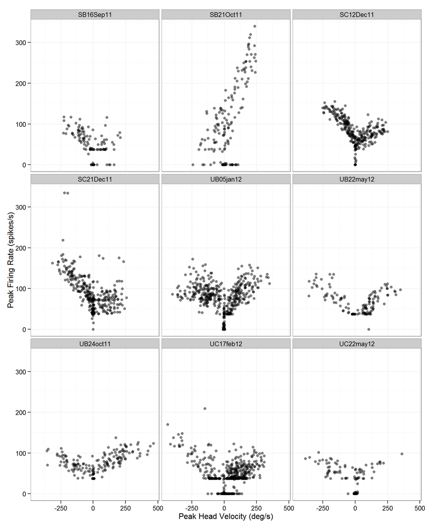

| Neuron | r.right | r.left | slope.right | slope.left | intercept.right | intercept.left | p.right | p.left |
| --- | --- | --- | --- | --- | --- | --- | --- | --- |
| SC12Dec11 | 0.304 | 0.654 | 0.148 | -0.306 | 57.458 | 76.192 | 0.000 | 0.000 |
| UC22may12 | 0.646 | 0.319 | 0.159 | -0.137 | 41.905 | 37.793 | 0.000 | 0.000 |
| SB21Oct11 | 0.618 | 0.227 | 1.157 | 0.381 | 26.610 | 106.125 | 0.000 | 0.001 |
| UB22may12 | 0.568 | 0.600 | 0.245 | -0.229 | 30.237 | 43.123 | 0.000 | 0.000 |
| UC17feb12 | 0.253 | 0.565 | 0.182 | -0.303 | 27.054 | 20.829 | 0.000 | 0.000 |
| SC21Dec11 | 0.015 | 0.486 | 0.061 | -0.387 | 66.903 | 73.054 | 0.218 | 0.000 |
| UB05jan12 | 0.456 | 0.036 | 0.273 | -0.052 | 53.744 | 82.269 | 0.000 | 0.007 |
| UB24oct11 | 0.397 | 0.437 | 0.123 | -0.136 | 66.765 | 51.448 | 0.000 | 0.000 |
| SB16Sep11 | 0.029 | 0.431 | 0.093 | -0.248 | 35.704 | 47.611 | 0.346 | 0.000 |
| SB10Oct11 | 0.376 | 0.088 | 0.415 | 0.103 | 151.171 | 65.653 | 0.000 | 0.001 |

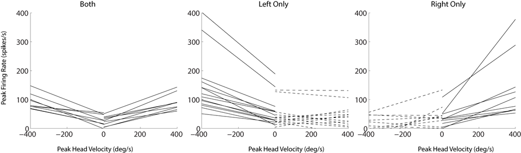

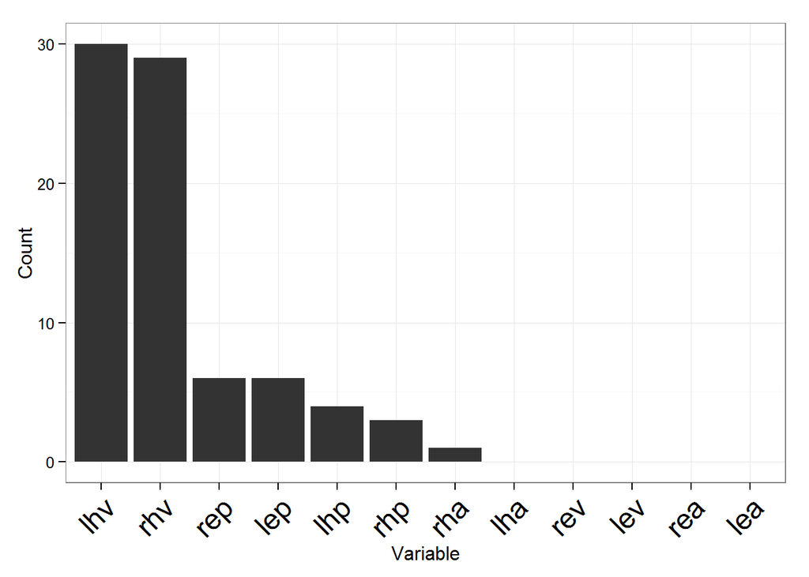

## Factors other than Head Velocity

| Neuron | shift | rsquared | f |
| --- | --- | --- | --- |
| SB21Oct11 | 120 | 0.77 | fr ~ 1 + rhv + rep |
| UB21dec11 | 60 | 0.70 | fr ~ 1 + lep |
| UB22may12 | 70 | 0.64 | fr ~ 1 + rhv + lhv |
| SE17Oct11 | 150 | 0.58 | fr ~ 1 + rhv |
| SB10Oct11 | 170 | 0.58 | fr ~ 1 + rhp + rhv |
| UC22may12 | 80 | 0.57 | fr ~ 1 + rhv + lhv |
| SC23Sep11 | 130 | 0.47 | fr ~ 1 + lhv |
| UBA4jun12 | 90 | 0.46 | fr ~ 1 + rhv + lhv |
| SD09Jan12 | 130 | 0.41 | fr ~ 1 + lhv |
| UB23mar12 | 80 | 0.40 | fr ~ 1 + lhv + rep |

### Static Position-Related Activity

Eye and head position are often correlated, so we include an additional analysis to determine what best explains the position-related activity observed in some cells. The design of our gaze shift task required subjects to initially maintain gaze fixation on a centrally located visual target with the eyes and head in one of three horizontal configurations. After the gaze shift, subjects were required to maintain gaze fixation of the second visual target without any further requirement for eye and head position. This enables us to dissociate eye and head position during fixations. Figure 3 shows a neuron with activity related to eye position. In the left panel, notice the activity after the gaze shift while the eyes and head are both to the right. In the right panel, we dissociate eye and head position during the fixation before the gaze shift and observe similar activity while the eyes are to the right in the orbits and the head is pointed leftward, indicating the activity is related to the rightward position of the eyes. This figure also shows the prediction of the model incorporating two terms: rightward head velocity and rightward eye position.

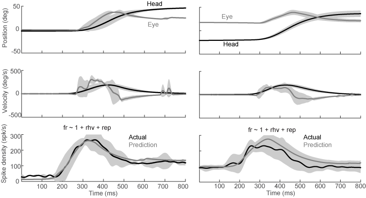

In order to assess the effect of eye and head position systematically, we limited trials to only the periods of fixation before and after gaze shifts, then fit a model with four terms, leftward and rightward eye and head position. This allowed us to determine how much each term contributes to the activity observed during fixation. When interpreting the mathematical models in terms of behaviors contributing to the neural activity, it is more useful to describe the activity as being related to rightward eye position, rather than negatively correlated with leftward eye position or rightward head position. In Table 3, we show the results of this regression, highlighting the term that contributes the most in terms of spikes/s per deg/s.

| Neuron | Position.Type | rsquared | Coefficient |
| --- | --- | --- | --- |
| UB21dec11 | Leftward.Eye | 0.95 | 7.96 |
| SB21Oct11 | Rightward.Eye | 0.76 | 2.16 |
| SC18Oct11 | Rightward.Head | 0.58 | 0.85 |
| SC28Nov11 | Rightward.Eye | 0.20 | 1.05 |
| SB10Oct11 | Rightward.Eye | 0.19 | 1.26 |
| UB05jan12 | Rightward.Head | 0.14 | 0.57 |
| UC03jan12 | Rightward.Eye | 0.11 | 0.39 |
| UB28sep11 | Rightward.Head | 0.11 | 0.42 |
| SB28Sep11 | Rightward.Head | 0.10 | 1.27 |
| SC16Sep11 | Rightward.Eye | 0.10 | 0.71 |
| SC07Oct11 | Rightward.Head | 0.09 | 0.66 |
| UC17feb12 | Rightward.Head | 0.08 | 0.17 |
| UB23mar12 | Rightward.Head | 0.03 | 0.15 |

## Task-Related Activity

The relatioship between firing rate and head velocity was largely consistent regardless of the task being performed. During the delayed gaze shift task, subjects typically executed a single, large gaze shift with varying head movements, depending on the amplitude of the movement and initial positions of the eyes in the orbits. During the visual pursuit task, subjects performed smooth gaze pursuit, with head movements driven by the velocity of the visual target and the initial positions of the eyes in the orbits. We did not record any neurons with activity limited to one behavior type. In the figure below, we compare the relationship between peak firing rate and the peak head velocity during the two tasks.

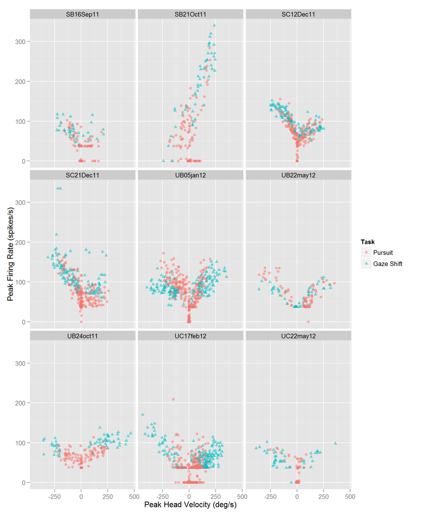

We investigate the impact of task type on the relationship between the peak head velocity and peak firing rate of the cell using ANCOVA by fitting the model $Fr_{peak} = x_{0}+x_{1} H_{peak}+x_{2} T_{type}+x_{3} H_{peak}*T_{type},$ where $Fr_{peak}$ is the peak firing rate, $H_{peak}$ is the peak head velocity, and $T_{type}$ is the task (delayed gaze shift or head-unrestrained pursuit) that was performed during each trial,and the $*$ indicates an interaction between the two parameters. For this analysis, we omitted trials where the peak head velocity did not exceed 40 deg/s, because we did not have an equal sampling of trials with little head movement from both task types. Using a threshold of p < 0.001, we identified cells for which we should reject the null hypothesis that the task is irrelevant for predicting the firing rate, once the head velocity is known. We show the cells meeting these criterea below.

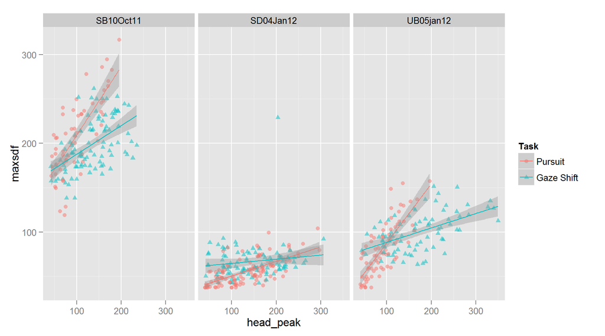

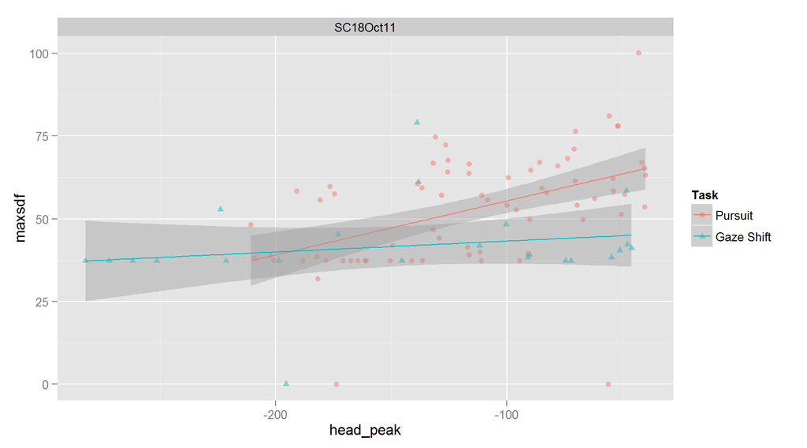

When we compare the cells identified using this method with the formula that these neurons were assigned during the multiple regression analysis, we can see that 3/4 of the cells have an additional factor besides head velocity that may explain why head velocity is insufficient to predict activity. The other cell cannot be explained in this fashion, but the firing rate overall is low (<100 spikes/s) and the R<sup>2</sup> of the fit for this cell is only 0.2.

| Neuron | formula | R.squared |
| --- | --- | --- |
| SB10Oct11 | fr ~ 1 + rhp + rhv | 0.5808505 |
| SC18Oct11 | fr ~ 1 + rhv + lep | 0.3302517 |
| SD04Jan12 | fr ~ 1 + rhv | 0.2022505 |
| UB05jan12 | fr ~ 1 + lhp + lhv + rha | 0.3867538 |

## Supplementary Figures

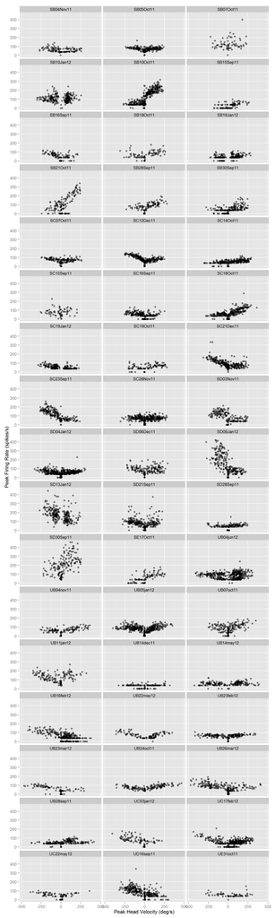

| Neuron | r.right | r.left | slope.right | slope.left | intercept.right | intercept.left | p.right | p.left |
| --- | --- | --- | --- | --- | --- | --- | --- | --- |
| SC12Dec11 | 0.304 | 0.654 | 0.148 | -0.306 | 57.458 | 76.192 | 0.000 | 0.000 |
| UC22may12 | 0.646 | 0.319 | 0.159 | -0.137 | 41.905 | 37.793 | 0.000 | 0.000 |
| SB21Oct11 | 0.618 | 0.227 | 1.157 | 0.381 | 26.610 | 106.125 | 0.000 | 0.001 |
| UB22may12 | 0.568 | 0.600 | 0.245 | -0.229 | 30.237 | 43.123 | 0.000 | 0.000 |
| UC17feb12 | 0.253 | 0.565 | 0.182 | -0.303 | 27.054 | 20.829 | 0.000 | 0.000 |
| SC21Dec11 | 0.015 | 0.486 | 0.061 | -0.387 | 66.903 | 73.054 | 0.218 | 0.000 |
| UB05jan12 | 0.456 | 0.036 | 0.273 | -0.052 | 53.744 | 82.269 | 0.000 | 0.007 |
| UB24oct11 | 0.397 | 0.437 | 0.123 | -0.136 | 66.765 | 51.448 | 0.000 | 0.000 |
| SB16Sep11 | 0.029 | 0.431 | 0.093 | -0.248 | 35.704 | 47.611 | 0.346 | 0.000 |
| SB10Oct11 | 0.376 | 0.088 | 0.415 | 0.103 | 151.171 | 65.653 | 0.000 | 0.001 |
| SC18Oct11 | 0.354 | 0.143 | 0.308 | 0.097 | 60.342 | 61.289 | 0.000 | 0.000 |
| SB28Sep11 | 0.314 | 0.010 | 0.247 | 0.033 | 76.825 | 75.540 | 0.000 | 0.600 |
| SC23Sep11 | 0.021 | 0.310 | -0.038 | -0.328 | 64.938 | 101.216 | 0.301 | 0.000 |
| UB04nov11 | 0.304 | 0.003 | 0.134 | -0.014 | 56.267 | 60.199 | 0.000 | 0.733 |
| UB11jan12 | 0.002 | 0.303 | 0.020 | -0.251 | 154.728 | 87.234 | 0.799 | 0.000 |
| SD04Jan12 | 0.062 | 0.302 | 0.071 | -0.176 | 52.538 | 40.258 | 0.000 | 0.000 |
| SC07Oct11 | 0.050 | 0.295 | 0.059 | -0.122 | 65.377 | 67.743 | 0.055 | 0.000 |
| UB16feb12 | 0.047 | 0.292 | -0.088 | -0.156 | 51.297 | 76.570 | 0.001 | 0.000 |
| SB15Sep11 | 0.263 | 0.000 | 0.199 | 0.007 | 21.735 | 15.119 | 0.000 | 0.942 |
| UB07oct11 | 0.235 | 0.121 | 0.241 | -0.207 | 81.641 | 64.925 | 0.000 | 0.007 |
| UB23mar12 | 0.235 | 0.224 | 0.104 | -0.109 | 30.225 | 57.881 | 0.036 | 0.001 |
| UB23feb12 | 0.225 | 0.114 | 0.071 | -0.048 | 59.175 | 55.344 | 0.000 | 0.002 |
| SD28Sep11 | 0.006 | 0.211 | 0.020 | -0.083 | 55.569 | 39.047 | 0.512 | 0.001 |
| SC19Jan12 | 0.000 | 0.195 | 0.004 | -0.132 | 43.758 | 46.568 | 0.881 | 0.000 |
| UB26mar12 | 0.191 | 0.167 | 0.100 | -0.109 | 56.852 | 79.533 | 0.000 | 0.000 |
| UB14dec11 | 0.132 | 0.169 | 0.082 | -0.099 | 24.195 | 17.731 | 0.003 | 0.002 |
| SB18Oct11 | 0.033 | 0.166 | 0.083 | -0.197 | 85.101 | 38.281 | 0.267 | 0.012 |
| SD06Dec11 | 0.013 | 0.158 | 0.063 | -0.214 | 86.885 | 77.936 | 0.273 | 0.003 |
| UC03jan12 | 0.148 | 0.136 | 0.100 | -0.135 | 50.517 | 72.491 | 0.141 | 0.003 |
| SC14Oct11 | 0.147 | 0.099 | 0.090 | 0.069 | 48.814 | 50.038 | 0.000 | 0.001 |
| SE17Oct11 | 0.135 | 0.055 | 0.157 | 0.126 | 77.346 | 41.837 | 0.013 | 0.168 |
| SB30Sep11 | 0.128 | 0.053 | 0.204 | -0.097 | 47.258 | 24.590 | 0.000 | 0.060 |
| SC16Sep11 | 0.114 | 0.124 | 0.178 | -0.122 | 27.140 | 47.973 | 0.002 | 0.000 |
| UE31oct11 | 0.119 | 0.108 | 0.101 | -0.066 | 38.291 | 53.576 | 0.036 | 0.126 |
| SD09Jan12 | 0.108 | 0.068 | -0.179 | -0.421 | 93.726 | 183.613 | 0.002 | 0.003 |
| UD16sep11 | 0.087 | 0.106 | -0.149 | -0.190 | 74.848 | 88.100 | 0.002 | 0.000 |
| SD13Jan12 | 0.000 | 0.098 | -0.019 | -0.387 | 145.790 | 159.871 | 0.868 | 0.000 |
| SB05Oct11 | 0.098 | 0.096 | 0.077 | -0.100 | 65.538 | 68.423 | 0.001 | 0.009 |
| UB04jun12 | 0.060 | 0.084 | 0.154 | -0.081 | 66.246 | 71.239 | 0.000 | 0.000 |
| SB19Jan12 | 0.080 | 0.031 | 0.110 | -0.096 | 39.337 | 29.375 | 0.001 | 0.141 |
| SC19Oct11 | 0.077 | 0.007 | 0.084 | -0.038 | 57.111 | 43.174 | 0.034 | 0.613 |
| SD21Sep11 | 0.057 | 0.066 | 0.276 | -0.161 | 65.910 | 75.314 | 0.025 | 0.001 |
| SB04Nov11 | 0.064 | 0.043 | 0.066 | -0.074 | 47.583 | 61.542 | 0.079 | 0.117 |
| UB28sep11 | 0.043 | 0.000 | -0.043 | -0.002 | 69.163 | 42.368 | 0.030 | 0.936 |
| SB10Jan12 | 0.038 | 0.022 | 0.175 | 0.082 | 90.784 | 121.889 | 0.028 | 0.100 |
| SD03Nov11 | 0.033 | 0.000 | 0.061 | 0.009 | 46.791 | 130.362 | 0.146 | 0.892 |
| SC15Sep11 | 0.023 | 0.000 | -0.086 | 0.006 | 100.157 | 84.997 | 0.525 | 0.964 |
| SD30Sep11 | 0.022 | 0.001 | 0.190 | 0.031 | 244.023 | 158.683 | 0.167 | 0.818 |
| SC28Nov11 | 0.001 | 0.020 | 0.007 | 0.046 | 74.874 | 80.704 | 0.760 | 0.094 |
| SB07Oct11 | 0.000 | 0.011 | -0.021 | -0.066 | 148.769 | 112.033 | 0.921 | 0.618 |
| UB14may12 | 0.000 | 0.009 | -0.002 | -0.020 | 60.904 | 48.794 | 0.945 | 0.368 |

| Neuron | shift | rsquared | f |
| --- | --- | --- | --- |
| SB21Oct11 | 120 | 0.77 | fr ~ 1 + rhv + rep |
| UB21dec11 | 60 | 0.70 | fr ~ 1 + lep |
| UB22may12 | 70 | 0.64 | fr ~ 1 + rhv + lhv |
| SE17Oct11 | 150 | 0.58 | fr ~ 1 + rhv |
| SB10Oct11 | 170 | 0.58 | fr ~ 1 + rhp + rhv |
| UC22may12 | 80 | 0.57 | fr ~ 1 + rhv + lhv |
| SC23Sep11 | 130 | 0.47 | fr ~ 1 + lhv |
| UBA4jun12 | 90 | 0.46 | fr ~ 1 + rhv + lhv |
| SD09Jan12 | 130 | 0.41 | fr ~ 1 + lhv |
| UB23mar12 | 80 | 0.40 | fr ~ 1 + lhv + rep |
| SC12Dec11 | 70 | 0.40 | fr ~ 1 + lhv |
| UB16feb12 | 90 | 0.40 | fr ~ 1 + lhv |
| UB05jan12 | 60 | 0.39 | fr ~ 1 + lhp + lhv + rha |
| SB15Sep11 | 110 | 0.37 | fr ~ 1 + rhv |
| UB28sep11 | 20 | 0.35 | fr ~ 1 + rhp + rhv + rep |
| SD03Nov11 | 160 | 0.34 | fr ~ 1 + lhv |
| SC18Oct11 | 40 | 0.33 | fr ~ 1 + rhv + lep |
| SB16Sep11 | 70 | 0.32 | fr ~ 1 + lhv |
| UD16sep11 | 130 | 0.32 | fr ~ 1 + lhv |
| UB04nov11 | 70 | 0.31 | fr ~ 1 + rhv + lhv |
| UBB4jun12 | 130 | 0.30 | fr ~ 1 + rhv + lhv |
| SB18Oct11 | 70 | 0.30 | fr ~ 1 + rhv |
| UB26mar12 | 80 | 0.30 | fr ~ 1 + lhv |
| UE31oct11 | 40 | 0.29 | fr ~ 1 + rhv + lhv |
| SC21Dec11 | 130 | 0.29 | fr ~ 1 + lhv |
| SC07Oct11 | 80 | 0.28 | fr ~ 1 + lhp + lhv |
| SD13Jan12 | 190 | 0.27 | fr ~ 1 + lhv |
| UC17feb12 | 100 | 0.26 | fr ~ 1 + lhv + rep |
| SC16Sep11 | 60 | 0.26 | fr ~ 1 + lhv + lep |
| UB24oct11 | 50 | 0.24 | fr ~ 1 + rhv |
| UC03jan12 | 110 | 0.23 | fr ~ 1 + lhv + rep |
| UB14may12 | 100 | 0.23 | fr ~ 1 + rhv + lhv |
| SC19Oct11 | 70 | 0.22 | fr ~ 1 + rhv |
| SD30Sep11 | 200 | 0.22 | fr ~ 1 + rhp + rhv |
| SC28Nov11 | 110 | 0.21 | fr ~ 1 + lhv + lep |
| SC14Oct11 | 180 | 0.20 | fr ~ 1 + rhv |
| SD04Jan12 | 60 | 0.20 | fr ~ 1 + rhv |
| SC19Jan12 | 190 | 0.20 | fr ~ 1 + lhv |
| SB28Sep11 | 50 | 0.19 | fr ~ 1 + rhv + lep |
| SD21Sep11 | 60 | 0.18 | fr ~ 1 + rhv + lhv |
| SB05Oct11 | 80 | 0.17 | fr ~ 1 + rhv + lhv |
| SB10Jan12 | 90 | 0.17 | fr ~ 1 + lhv + lep |
| SB30Sep11 | 130 | 0.16 | fr ~ 1 + rhv |
| SB19Jan12 | 120 | 0.16 | fr ~ 1 + rhv |
| SD06Dec11 | 50 | 0.15 | fr ~ 1 + rhv + lhv |
| SB04Nov11 | 90 | 0.15 | fr ~ 1 + rhv + lhv |
| UB07oct11 | 80 | 0.14 | fr ~ 1 + lhp + rhv |
| UB23feb12 | 50 | 0.13 | fr ~ 1 + rhv |
| SD28Sep11 | 130 | 0.09 | fr ~ 1 + rep |
| UB11jan12 | 40 | 0.06 | fr ~ 1 + lhp |
| SB07Oct11 | 200 | 0.05 | fr ~ 1 + rhv |
| SC15Sep11 | 20 | 0.00 | fr ~ 1 |
| UB14dec11 | 20 | 0.00 | fr ~ 1 |

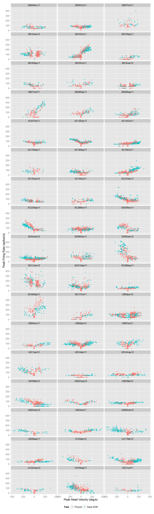